# Aside

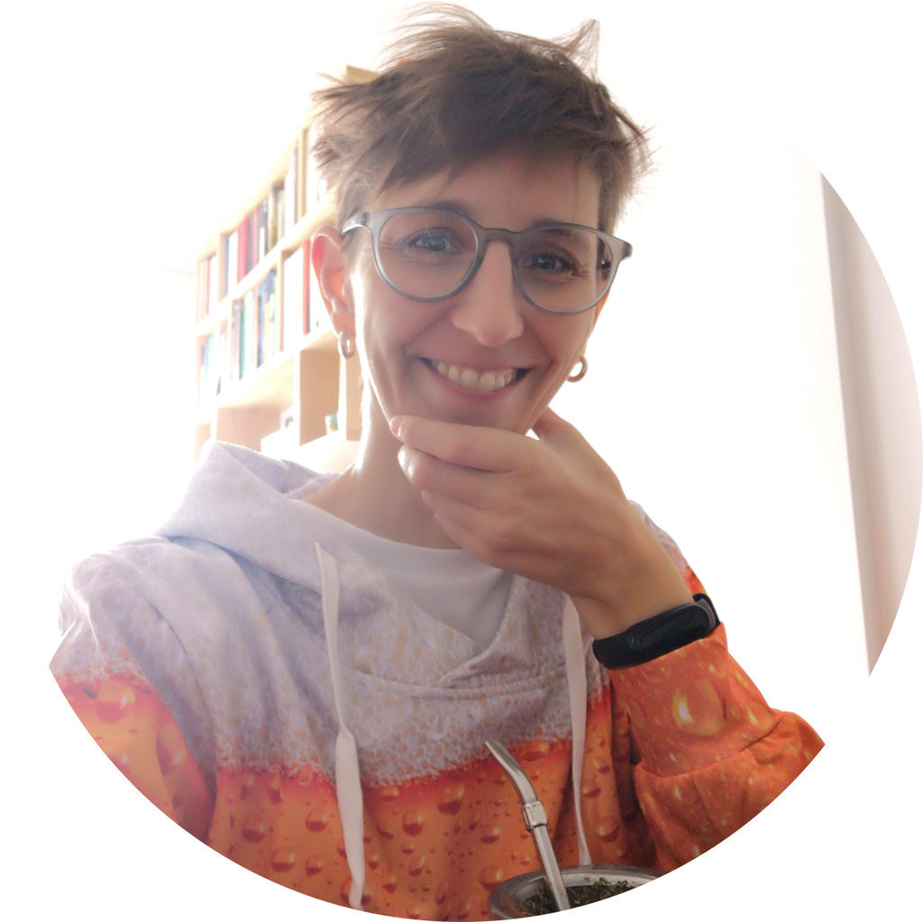

## Contact

- [veroandreo.github.io](https://veroandreo.github.io/)
- veroandreo@gmail.com
- [github.com/veroandreo](https://github.com/veroandreo/)

## Skills

GRASS

R

Bash

Python

LaTeX

Markdown

QGIS

GEE

git

HTML - CSS

## Languages

- Spanish (Native Speaker)
- English (C1)
- Italian (A2)

# Main

## Veronica Andreo

I am a biologist and I hold a PhD in Biological Sciences and an MSc in Remote Sensing and GIS applications. I work as a **researcher** for [CONICET](https://www.conicet.gov.ar/) at [Gulich Institute](http://ig.conae.unc.edu.ar/) of the Argentinian Space Agency [(CONAE)](https://www.argentina.gob.ar/ciencia/conae) in Córdoba, Argentina. My research is focused on uncovering environmental drivers of vector-borne disease outbreaks through statistical and machine learning methods. I am mostly interested in environmental features/changes that can be derived from **satellite image analysis, remote sensing time series and GIS-based techniques**.

I am part of the [**GRASS**](https://grass.osgeo.org/) Development team and serve as [**PSC chair**](https://trac.osgeo.org/grass/wiki/PSC). I am a strong advocate for [OSGeo](https://www.osgeo.org/) and free and open source software for geo-spatial (FOSS4G).

## Research Experience

### Associate Researcher (CIC-CONICET)

Gulich Institute, CONAE-UNC.

Córdoba, AR

Current - 2023

- Develop workflows to obtain and process satellite data for public health applications. Explore different types of data analysis, modeling and visualization to gain new perspectives.
- Write scientific publications and grant proposals. Present at national and international conferences. Review papers and thesis. Supervise MSc and PhD students.
- Network and collaborate with colleagues in different areas and from different countries.

### Visiting Scholar

Center for Geospatial Analytics, NC State University (NCSU).

Raleigh, USA

2024

- Temporary position (6 months). NSF POSE II grant to enhance GRASS Ecosystem.

### Assistant Researcher (CIC-CONICET)

Gulich Institute, CONAE-UNC.

Córdoba, AR

2023 - 2018

- Develop workflows to obtain and process satellite data for public health applications. Explore different types of data analysis, modeling and visualization to gain new perspectives.
- Write scientific publications and contribute to grant writing. Present at national and international conferences. Review papers and thesis. Supervise students.
- Network and collaborate with colleagues in different areas and from different countries.

### Postdoctoral Researcher

Earth Observation Sciences (EOS). ITC. University of Twente.

Enschede, NL

2018 - 2016

- Conducted research on methods to reconstruct missing data in remote sensing time series and obtain relevant variables to be used in mosquito-borne disease outbreak prediction.
- Wrote scientific publications and reports. Presentated at international conferences.
- Assisted with teaching and supervised MSc students.
- Developed skills to work in international and multi-cultural environment.

### GIS technician

Fondazione Edmund Mach (FEM).

San Michele all’Adige, IT

2015

- Conducted statistical analysis and modeling of tick-borne and mosquito-borne diseases for different European countries.
- Delivered written report and contributed to scientific publication.

### Graduate research assistant

National University of Río Cuarto.

Río Cuarto, AR

2012 - 2006

- Carried out field and laboratory work such as rodent trapping and processing, vegetation censuses.
- Data Analysis: Statistics, Species Distribution Models - SDM, Remote Sensing processing and analysis, Supervised and un-supervised classification, GIS.
- Wrote scientific publications and reports. Presentated at national and international conferences.

### Under-graduate research assistant

National University of Río Cuarto.

Río Cuarto, AR

2006 - 2004

- Field and laboratory work: rodent trapping and processing, vegetation censuses.
- Performed data compilation and statistical analysis.
- Processed and analized NOAA-AVHRR, Lansat TM and ETM scenes.

## Education

### MSc Spatial Applications for Early Warning and Response to Emergencies

National University of Córdoba.

Córdoba, AR

2015 - 2012

### PhD Biology

National University of Río Cuarto.

Río Cuarto, AR

2012 - 2007

### Lic. Biology

National University of Río Cuarto.

Río Cuarto, AR

2005 - 2000

Note: *Licenciatura* (Lic) is a 5-year course of studies oriented to research.

## Stays abroad

### Short stay - Visiting Scholar

Center for Geospatial Analytics, North Carolina State University (NCSU).

Raleigh, USA

2023

- Talk and workshop for the Geospatial Forum.
- Networking meetings with reseachers to explore collaboration opportunities.
- Discuss funding opportunities.

### Research stay - EOXPOSURE. H2020 Marie Curie RISE project

Royal Military Academy (RMA).

Brussels, BE

2022

- Validation and testing of mosquito egg counting algorithm with ovitrap sticks pictures.
- Developed and translated quick and detailed user guides.
- Advisors: **Dr. Michal Shimoni** and **Dr. Rob Haelterman**.

### Research stay - EOXPOSURE. H2020 Marie Curie RISE project

Royal Military Academy (RMA) and Université Libre de Bruxelles (ULB).

Brussels, BE

2019

- Applied Object Based Image Analysis and Machine Learning for Very High Resolution Image Classification in urban areas.
- Participated of a one-week hackathon on Deep Learning. We presented those results at FOSS4G Belgium.
- Advisors: **Dr. Michal Shimoni** and **Dr. Moritz Lennert**.

### Research stay - GEOSAFE. H2020 Marie Curie RISE project

Royal Melbourne Institute of Technology (RMIT).

Melbourne, AU

2018

- Conducted a review of remote sensing for fire detection and mapping.
- Designed a workflow to validate active fire products.
- Advisors: **Dr. Marc Demange** and **Dr. Karin Reinke**.

### Research stay - ASI Scholar

Fondazione Edmund Mach (FEM).

San Michele all’Adige, IT

2013

- Received training on GRASS GIS.
- Advisor: **Dr. Markus Neteler**.

### Research stay - Fulbright scholar

Johns Hopkins Bloomberg School of Public Health.

Baltimore, MD - USA

2009

- Received training on Spatial Epidemiology, GIS and remote sensing methods to model hantavirus host distribution at different spatial scales.
- Advisor: **Dr. Gregory Glass**.

### Research stay

Center for Advanced Studies in Ecology and Biodiversity CASEB, Pontificia Universidad Católica de Chile.

Santiago, CL

2007

- Conducted research on population dynamics modeling.
- Advisor: **Dr. Mauricio Lima**.

## Consultancies and technical reports

### Distribution of *Orthohantavirus* rodent hosts in the southern cone

Ministry of Environment and Sustainable Development.

Buenos Aires, AR

2024

- Developed workflows and modeled current climatic suitability for *Orthohantavirus* rodent hosts.

### Dengue and Climate Change

Ministry of Environment and Sustainable Development.

Buenos Aires, AR

2022

- Developed workflows for modeling current and future climatic suitability for *Aedes aegypti*.
- Assissted with modeling of Dengue fever distribution and potential spread in the future.

### Distribution of phlebotomine sandflies in Córdoba

Health Ministry of Córdoba.

Córdoba, AR

2022

- Analyzed the distribution and types habitats where canine visceral leishmaniasis and phlebotomine species were found in the city of Córdoba.

### *Aedes aegypti* and Dengue in Córdoba city

Gulich Institute, CONAE-UNC.

Córdoba, AR

2020 - 2019

- Coordinated the writing of a technical report summarizing our group contributions.
- Developed open source based workflows to obtain mosquito distribution maps and dengue incidence.

### Sentinel 2 processing chain

Consultant for [SIRIS](http://www.sistemasiris.org/) project.

Córdoba, AR

2020

- Provided technical support about GRASS GIS modules to develop a workflow to process and analyze Sentinel 2 data for agriculture.

### Remote sensing products of relevance for Chagas disease

Consultant for TDR project.

Córdoba, AR

2016

- Developed automatic routines to download and process MODIS and TRMM satellite products.
- Derived environmental layers to be used as predictors of disease risk.

### Remote sensing derived products for flood mapping

Consultant for UDEGE project.

Córdoba, AR

2015

- Implemented algorithms to identify flooded areas in central Argentina using open source tools.
- Implemented an algorithm of flood risk according to flood maps and rainfall forecasts using open source tools.

### Time series analysis of ocean color satellite products

Consultant for CONAE.

Córdoba, AR

2014

- Performed analysis of missing data, gap-filling, modeling and reconstruction of time series of MODIS Aqua chlorophyll product.
- Performed analysis of climatologies and anomalies.
- Delivered written reports.

### Meteorological fire danger index

Consultant for the National University of Córdoba.

Córdoba, AR

2014

- Implementated a meteorological fire danger index algorithm in GRASS GIS using weather forecast data.

## Scientific publications

### Spatio-Temporal Modeling of Dengue in Argentina (2009–2025): Risk Factors, spatial patterns, and implications for prevention planning

Piette, J.; Linard, C.; Morlighem, C; **Andreo, V.** Submitted to *International Journal of Health Geographics*.

N/A

N/A

### Spatial accessibility to health services in the Argentina–Paraguay border region of the Gran Chaco

Rodriguez Gonzalez, C.; Ávila, S.; Cardone, K.; Fernández, M.; Crudo, F.; Periago, M. V.; **Andreo, V.** Submitted to *BMC Health Services Research*.

N/A

N/A

### Tutorials for the GRASS geocomputation engine

Harmon, B.; **Andreo, V.**; Petrasova, A.; Petras, V.; Haedrich, C.; White, C. Submitted to *Journal of Open Source Education*.

N/A

N/A

### GRASS as a Geocomputational Engine

Harmon, B.; Petrasova, A.; Petras, V.; White, C.; **Andreo, V.**; van Breugel, P.; Cho, H.; Neteler, M. Submitted to *Progress in Physical Geography*.

N/A

N/A

### Environment-based strategy for monitoring early colonization of Lutzomyia longipalpis at the city scale

Quintana, M. G.; **Andreo, V.**; Cavia, R.; Santini, M. S.; Moya, S. L.; Estrada Méndez, L.; Salomon, O. *Journal of Medical Entomology* 63(4). [DOI](https://doi.org/10.1093/jme/tjag112).

N/A

2026

### Distribution and richness of Orthohantavirus reservoir hosts: Implications for zoonotic risk in Southern South America

Pinotti, J. D.; **Andreo, V.** *Acta Tropica* 281,108234. [DOI](https://doi.org/10.1016/j.actatropica.2026.108234).

N/A

2026

### How much can mosquito population dynamics models inform entomological surveillance? Assessing the transferability of Aedes aegypti climate-driven models in Argentina

San Miguel, T.; Da Re, D.; Espinosa, M. O.; Periago, M. V.; Lopez, L.; Guzman, C.; **Andreo, V.** *Acta Tropica* 280, 108204. [DOI](https://doi.org/10.1016/j.actatropica.2026.108204).

N/A

2026

### Distribution of mother-to-child transmitted (MTCT) infections and Socioeconomic vulnerability within the Gran Chaco region

N/A

2026

### AedesTraits: A global dataset of temperature–dependent trait responses in Aedes mosquitoes

Da Re, D.; **Andreo, V.**; San Miguel, T.; Blaha, M.; Rosá, R.; Rizzoli, A.; Harrison, J.; Sorek, S.; Johnson, L. R.; Huxley, P. *Scientific Data*. [DOI](https://doi.org/10.1038/s41597-025-06461-z).

N/A

2025

### A systematic review of remote sensing data in studying the association of air pollution and Asthma/Allergic Rhinitis

Coiman, A.; Garcia Ferreyra, M. F.; **Andreo, V.** *Revista de Salud Pública*. [DOI](https://doi.org/10.31052/1853.1180.v31.n2.47409).

N/A

2025

### Orthohantavirus Hosts and Genotypes in Southern South America: An Updated Review

Ortiz, N.; Pinotti, J.; **Andreo, V.**; González-Ittig, R.; Gardenal, C. N. *PLOS NTD*. [DOI](https://doi.org/10.1371/journal.pntd.0013489).

N/A

2025

### A systematic review of Aedes aegypti population dynamics models based on differential equations

San Miguel, T.; Da Re, D.; **Andreo, V.** *Acta Tropica*. [DOI](https://doi.org/10.1016/j.actatropica.2024.107459)

N/A

2024

### Remote sensing biodiversity monitoring in Latin America: Emerging need for sustained local research and regional collaboration to achieve global goals.

Garzon-Lopez, C. X.; Miranda, A.; Moya, D.; **Andreo, V.** *Global Ecology and Biogeography*. [DOI](https://doi.org/10.1111/geb.13804).

N/A

2024

### Combining phylogeography and ecological niche modeling to infer the evolutionary history of the Cordoba vesper mouse (*Calomys venustus*).

Pinotti, J. D.; Martin, M. L.; Chiappero, M. B.; **Andreo, V.**; Gonzalez-Ittig, R. E. *Integrative Zoology*. [DOI](https://doi.org/10.1111/1749-4877.12805).

N/A

2024

### A geospatial analysis of cardiometabolic diseases and their risk factors considering environmental features in a midsized city in Argentina.

Campero, M.; Scavuzzo, C. M.; **Andreo, V.**; Mileo, M.; Franzois, M.; Oberto, M.; Gonzalez Rodriguez, C.; Defagó, M.D. *Geospatial Health* 18(2). [DOI](https://doi.org/10.4081/gh.2023.1212).

N/A

2023

### Using VHR satellite imagery, OBIA and landscape metrics to improve mosquito surveillance in urban areas

Rodriguez Gonzalez, C.; Guzman, C.; **Andreo, V.** *Ecological Informatics* 77, 102221. [DOI](https://doi.org/10.1016/j.ecoinf.2023.102221).

N/A

2023

### Risk Stratification to Guide Prevention and Control Strategies for Arboviruses Transmitted by *Aedes aegypti*

Espinosa, M.O.; **Andreo, V.**; Paredes, G.; Leaplaza, C.; Heredia, V.; Periago, M.V.; Abril, M. *Tropical Medicine and Infectious Disease* 8, 362. [DOI](https://doi.org/10.3390/tropicalmed8070362).

N/A

2023

### Ovitrap Monitor - Online application for counting mosquito eggs and visualisation toolbox in support of health services

Hamesse, C.; **Andreo, V.**; Rodriguez Gonzalez, C.; Beumier, C.; Rubio, J.; Porcasi, X.; Lopez, L.; Guzman, C.; Haelterman, R.; Shimoni, M.; Scavuzzo, C.M. *Ecological Informatics* 75, 102105. [DOI](https://doi.org/10.1016/j.ecoinf.2023.102105).

N/A

2023

### Colilargo’s occupancy and the role of native and exotic plants in hantavirus expansion and transmission risk

Contreras, F.; **Andreo, V.**; Hechem, V.; Polop, J.; Provensal, M.C. *Mammal Research* 68, 167-176. [DOI](https://doi.org/10.1007/s13364-023-00671-9).

N/A

2023

### Ecological characterization of a Cutaneous Leishmaniasis outbreak through remotely sensed land cover changes

**Andreo, V.**; Rosa, J.; Ramos, K.; Salomon, O. D. *Geospatial Health* 17, 1033. [DOI](https://doi.org/10.4081/gh.2022.1033).

N/A

2022

### A zero-inflated mixture spatially varying coefficient modeling of cholera incidences

Osei, F.B.; Stein, A.; **Andreo, V.** *Spatial Statistics* 48, 100635. [DOI](https://doi.org/10.1016/j.spasta.2022.100635).

N/A

2022

### The Distribution of Phlebotominae (Diptera, Psychodidade) species and human cases of leishmaniasis in the Province of Corrientes, Argentina

Villarquide, M. L.; **Andreo, V.**; Salomon, O. D.; Santini, M. S. *Revista de la Sociedad Entomológica Argentina* 81, 55-63. [DOI](https://doi.org/10.25085/rsea.810409).

N/A

2022

### Spatial Distribution of Aedes aegypti Oviposition Temporal Patterns and Their Relationship with Environment and Dengue Incidence

**Andreo, V.**; Porcasi, X.; Guzman, C.; Lopez, L.; Scavuzzo, C. M. *Insects* 12, 919. [DOI](https://doi.org/10.3390/insects12100919).

N/A

2021

- Code hosted at: https://github.com/veroandreo/mosquito-ts-clust

### Implementation of a proactive system to monitor *Aedes aegypti* populations using open access historical and forecasted meteorological data

Aguirre, E.; **Andreo, V.**; Porcasi, X.; Lopez, L.; Guzman, C.; Gonzalez, P.; Scavuzzo, C. M. *Ecological Informatics* 64, 101351. [DOI](https://doi.org/10.1016/j.ecoinf.2021.101351).

N/A

2021

- Code hosted at: https://github.com/CONAE-GVT/aedes_aegypti/tree/master
- App: http://pluton.hopto.org:8080/app/

### Towards a workflow for operational mapping of *Aedes aegypti* at urban scale based on remote sensing

**Andreo, V.**; Cuervo, P. F.; Porcasi, X.; Lopez, L.; Guzman, C.; Scavuzzo, C. M. *Remote Sensing Applications: Society and Environment* 23, 100554. [DOI](https://doi.org/10.1016/j.rsase.2021.100554).

N/A

2021

- Code hosted at: https://github.com/veroandreo/aedes-urban-maps

### Challenging population dynamics models with new data: How accurate were our inferences?

**Andreo, V.**; Lima, M.; Polop, J.; Provensal, C. *Mastozoologia Neotropical* 27, 8-16. [DOI](https://doi.org/10.31687/saremMN.20.27.1.0.17).

N/A

2020

### Multiple refugia and glacial expansions in the Tucumane-Bolivian Yungas: the phylogeography and potential distribution modelling of *Calomys fecundus* (Rodentia: Cricetidae)

Pinotti, J. D.; Ferreiro, A. M.; Martin M. L.; Levis, S.; Chiappero, M.; **Andreo, V.**; Gonzalez-Ittig, R. E. *Journal of Zoological Systematics and Evolutionary Research* 58, 23-36. [DOI](https://doi.org/10.1111/jzs.12375).

N/A

2020

### On parameterizing soil evaporation in a direct remote sensing model of ET: PT‐JPL

Marshall, M.; Tu, K.; **Andreo, V.** *Water Resources Research* 56, e2019WR026290. [DOI](https://doi.org/10.1029/2019WR026290).

N/A

2020

### A novel method based on time series satellite data analysis to detect algal blooms

Germán, A.; **Andreo, V.**; Tauro, C.; Scavuzzo, C. M.; Ferral, A. *Ecological Informatics* 59, 101131. [DOI](https://doi.org/10.1016/j.ecoinf.2020.101131).

N/A

2020

### Modelling and mapping the intra-urban spatial distribution of Plasmodium falciparum parasite rate standardized to the age group 2-10 years using Very-High-Resolution Satellite Derived Indicators in Sub-Saharan African Cities

Georganos, S.; Brousse, O.; Dujardin, S.; Linard, C.; Casey, D.; Milliones, M.; Parmentier, B.; van Lipzig, N.; Demuzere, M.; Grippa, T.; Vanhuysse, S.; Mboga, N.; **Andreo, V.**; Snow, R. W.; Lennert, M. *International Journal of Health Geographics* 19, 38. [DOI](https://doi.org/10.1186/s12942-020-00232-2).

N/A

2020

### Rodents and satellites: Predicting mice abundance and distribution with Sentinel-2 data

**Andreo, V.**; Belgiu, M.; Brito Hoyos, D.; Osei, F.; Provensal, C.; Stein, A. *Ecological Informatics* 51, 157-167. [DOI](https://doi.org/10.1016/j.ecoinf.2019.03.001).

N/A

2019

### Effect of climate and habitat type on the spatio-temporal variability of tick-borne bacteria in Europe

Rosà, R.; **Andreo, V.**; Tagliapietra, V.; Barakova, I.; Arnoldi, D.; Hauffe, H.; Manica, M.; et al. *International Journal of Environmental Research and Public Health* 15, 732. [DOI](https://doi.org/10.3390/ijerph15040732).

N/A

2018

### Mapping risk: where must we put our efforts to prevent the establishment of invasive species?

Natale, E.; Reinoso, H.; **Andreo, V.**; Zalba, S. *Ecologia Austral* 28, 81-92. [DOI](https://doi.org/10.25260/EA.18.28.1.0.553).

N/A

2018

### A New Fully Gap-Free Time Series of Land Surface Temperature from MODIS LST Data

Metz, M.; **Andreo, V.**; Neteler, M. *Remote Sensing* 9, 1333. [DOI](https://doi.org/10.3390/rs9121333).

N/A

2017

### Genetic population structure of the long-tailed pygmy rice rat (Rodentia, Cricetidae) at different geographic scales in the Argentinean Patagonia

Ortiz, N.; Polop, F.; **Andreo, V.**; Provensal, M.; Polop, J.; Gardenal, C.; Gonzalez-Ittig, R. E. *Journal of Zoology* 301, 215-226. [DOI](https://doi.org/10.1111/jzo.12410).

N/A

2017

### Remote sensing of phytoplankton blooms in the Continental Shelf and shelf-break of Argentina: spatio-temporal changes and phenology

**Andreo, V.**; Dogliotti, A.; Tauro, C. *IEEE JSTARS* 9, 5315-5324. [DOI](https://doi.org/10.1109/JSTARS.2016.2585142).

N/A

2016

### Temporal fine-scale genetic variation in populations of the long-tailed pygmy rice rat from Patagonia, Argentina: its relationship with high levels of migration

González-Ittig, R.; Polop, F.; **Andreo, V.**; Chiappero, M.; Provensal, C.; Polop, J.; Gardenal, C. *Journal of Zoology* 296,216-224. [DOI](https://doi.org/10.1111/jzo.12238).

N/A

2015

### Potential of remote sensing to predict species invasions - a modeling perspective

Rocchini, D.; **Andreo, V.**; Förster, M.; Garzon-Lopez, C.X.; Gutierrez, A.P.; Gillespie ,T.W.; Hauffe, H.C.; et al. *Progress in Physical Geography* 6, 201-222. [DOI](https://doi.org/10.1177/0309133315574659).

N/A

2015

### Estimating Hantavirus risk in southern Argentina: A GIS-based approach combining human cases and host distribution

**Andreo, V.**; Neteler, M.; Rocchini, D.; Provensal, C.; Levis, S.; Porcasi, X.; Rizzoli, A.; Lanfri, M.; Scavuzzo, M.; Pini, N.; Enria, D.; Polop, J. *Viruses* 6, 201222. [DOI](https://doi.org/10.3390/v6010201).

N/A

2014

### Summer–autumn distribution and abundance of the hantavirus host, *Oligoryzomys longicaudatus*, in northwestern Chubut, Argentina

**Andreo, V.**; Provensal, C.; Levis, S.; Pini, N.; Enría, D.; Polop, J. *Journal of Mammalogy* 93, 1559-1568. [DOI](https://doi.org/10.1644/11-MAMM-A-201.1).

N/A

2012

### Environmental variables in spatial dynamics of *Oligoryzomys longicaudatus* (Andes hantavirus reservoir) in North West of Chubut province, Argentina. PhD dissertation abstract

**Andreo, V.** *Mastozoologia Neotropical* 19, 179-181 (in Spanish).

N/A

2012

### Scientific training and professional field in Biological sciences: an educational proposal at the University

Rivarosa, A.; Correa, A. L.; **Andreo, V.** *Revista de Educación en Biología* 15, 69-81 (in Spanish).

N/A

2012

### Modeling potential distribution of *Oligoryzomys longicaudatus*, the Andes Virus (Genus: Hantavirus) reservoir, in Argentina

**Andreo, V.**; Glass, G.; Shields, T.; Provensal, C.; Polop, J. *EcoHealth* 8, 332-348. [DOI](https://doi.org/10.1007/s10393-011-0719-5).

N/A

2011

### Software Development for the Use of Space Information in Spatial and temporal Simulation of Rodent Population Dynamics

Musso, V.; Provensal, M. C.; Priotto, J.; **Andreo, V.**; Simone, I.; Piacenza, F.; Polop, F.; et al. *Acta Biologica Venezuélica* 31, 23-26 (in Spanish).

N/A

2011

### Population dynamics of two rodent species in agro-ecosystems of central Argentina: Intra-specific competition, land-use and climate effects

**Andreo, V.**; Lima, M.; Provensal, M. C.; Priotto, J. W.; Polop, J. J. *Population Ecology* 51, 297-306. [DOI](https://doi.org/10.1007/s10144-008-0123-3).

N/A

2009

### Environmental factors and population fluctuations of *Akodon azarae* (Rodentia, Muridae) in central Argentina

**Andreo, V.**; Provensal, M. C.; Lamfri, M.; Scavuzzo, M.; Polop, J. J. *Austral Ecology* 34, 132-142. [DOI](https://doi.org/10.1111/j.1442-9993.2008.01889.x).

N/A

2009

## Conference papers

### Assessing the accuracy of global meteorological datasets for climate-sensitive disease vector modelling: insights from Argentina

San Miguel, T.; Da Re, D.; **Andreo, V.** XXI RPIC. [DOI](https://doi.org/10.1109/RPIC67987.2025.11260742).

San Francisco, AR

2025

### Predicting asthma mortality in Argentina using remote sensing data and machine learning

Coiman, A.; Garcia Ferreyra, M. F.; **Andreo, V.** XXI RPIC. [DOI](https://doi.org/10.1109/RPIC67987.2025.11260709).

San Francisco, AR

2025

### One-way sensitivity analysis of an ODE-based *Aedes aegypti* model driven by meteorological data

San Miguel, T. V.; Sgró, M. A.; **Andreo, V.** MACI, 10: 606-609.

Córdoba, AR

2025

### Unveiling Argentina’s heatwaves: A comprehensive and open analysis of the last 30 years using the ERA5-Land Reanalysis Product

Pinotti, J.D.; **Andreo, V.**; Muñoz, S.; Koristschoner, J.; Porcasi, X. *XX RPIC*. [DOI](https://doi.org/10.1109/RPIC59053.2023.10530696).

Oberá, AR

2023

### Evaluación del riesgo epidemiológico de leptospirosis en la ciudad de Rosario (Santa Fe, Argentina), durante el período 2013-2015

Balparda, L.; Pagura, J.; **Andreo, V.** *XX Simposio Internacional SELPER*.

Monterrey, MX

2022

### Environmental characterisation of an urban area to assess the distribution of Aedes aegypti monitoring

Rodriguez Gonzalez, C.; Guzman, C.; **Andreo, V.** *2022 IEEE Biennial Congress of Argentina (ARGENCON)*, 1-6. [DOI](https://doi.org/10.1109/ARGENCON55245.2022.9939758).

San Juan, AR

2022

### Calculation of surface urban heat index from LANDSAT-8 TIRS data and its relation with land

Ferral, A.; Gili, A.; **Andreo, V.**; German, A.; Beltramone, G.; Bonansea, M.; Pana, S.; Scavuzzo, C.M. *XIX RPIC*. [DOI](https://doi.org/10.1109/RPIC53795.2021.9648422).

San Juan, AR

2021

### Predicting *Aedes aegypti* eggs count using remote sensing data and a generalized linear model

Mudele, O.; **Andreo,V.**; Porcasi, M.; Scavuzzo, C.M.; Lopez, L.; Gamba, P. *2021 IEEE International Geoscience and Remote Sensing Symposium IGARSS*, 84-87. [DOI](https://doi.org/10.1109/IGARSS47720.2021.9554002).

Bruselas, BE

2021

### Semi-automatic tool to count mosquito eggs in ovitrap sticks images

Beumier, C.; Rubio, J.; **Andreo, V.**; Guzman, C.; Porcasi, X.; Scavuzzo, C.M.; Shimoni, M. *2021 IEEE International Geoscience and Remote Sensing Symposium IGARSS*, 80-83. [DOI](https://doi.org/10.1109/IGARSS47720.2021.9555005).

Bruselas, BE

2021

### Estimating the significance of predictor variables in machine learning epidemiological models using SHAP

Scavuzzo, J. M.; Scavuzzo, C. M.; Espinosa, M.; **Andreo, V.**; Campero, M. N.; Periago, V.; Abril, M. *ARGENCON*, 1-6. [DOI](https://doi.org/10.1109/ARGENCON49523.2020.9505575) (In Spanish).

Online conference

2020

### Time series clustering applied to Eco-epidemiology: the case of *Aedes aegypti* in Córdoba, Argentina

**Andreo, V.**; Porcasi, X.; Rodriguez, C.; Lopez, L.; Guzman, C.; Scavuzzo, C. M. *Proceedings of the 2019 XVIII Workshop on Information Processing and Control (RPIC)*, 93-98. [DOI](https://doi.org/10.1109/RPIC.2019.8882184).

Bahía Blanca, AR

2019

### Spatial analysis of *Aedes aegypti* activity for public health surveillance

Porcasi, X.; **Andreo, V.**; Aguirre, E.; Rojas, N.; Rubio, J.; Frutos, N.; Guzman, C.; Lopez, L. *Proceedings of the 2019 XVIII Workshop on Information Processing and Control (RPIC)*, 214-217. [DOI](https://doi.org/10.1109/RPIC.2019.8882135).

Bahía Blanca, AR

2019

### Identifying favorable spatio-temporal conditions for West Nile virus outbreaks by co-clustering of MODIS LST indices time series

**Andreo, V.**; Izquierdo-Verdiguier, E.; Zurita-Milla, R.; Rosà, R.; Rizzoli, A.; Papa, A. *Proceedings of the IEEE International Geoscience and Remote Sensing Symposium IGARSS*, 4670-4673. [DOI](https://doi.org/10.1109/IGARSS.2018.8519542)

Valencia, ES

2018

### Regional scale environmental variables complementing a Risk Model of Chagas Disease vectorial transmission

Porcasi, X.; **Andreo, V.**; Ferral, A.; Guimarey, P.; Santini, M. S.; Spillmann, C.; Hernandez, R.; Geuna Serra, A.; Aguirre, E. *2018 IEEE Biennial Congress of Argentina (ARGENCON)*, 1-5. [DOI](https://doi.org/10.1109/ARGENCON.2018.8646185).

Tucumán, AR

2018

### Fostering pre-university student participation in OSGeo through the Google Code-In competition

Rautenbach, V.; Leo, M.D.; **Andreo, V.**; Delucchi, L.; Kudrnovsky, H.; McKenna, J.; Acosta y Lara, S. *ISPRS - International Archives of the Photogrammetry, Remote Sensing and Spatial Information Sciences. XLII-4/W8*, 175-180. [DOI](https://doi.org/10.5194/isprs-archives-XLII-4-W8-175-2018).

Dar es Salaam, TZ

2018

### Can reconstructed land surface temperature from space predict a West Nile virus outbreak?

**Andreo, V.**; Metz, M.; Neteler, M.; Rosà, R.; Marcantonio, M.; Billinis, C.; Rizzoli, A.; Papa, A. *ISPRS - International Archives of the Photogrammetry, Remote Sensing and Spatial Information Sciences. XLII-4/W2*, 19-26. [DOI](https://doi.org/10.5194/isprs-archives-XLII-4-W2-19-2017).

Paris, FR

2017

### Analysis of a chlorophyll-a time series derived from MODIS imagery

Germán, A.; Tauro, C.; **Andreo, V.**; Bernasconi, I. and A. Ferral. *Proceedings of the 2016 IEEE Biennial Congress of Argentina (ARGENCON)* 1-6. [DOI](https://doi.org/10.1109/ARGENCON.2016.7585365).

Buenos Aires, AR

2016

### Spatio-temporal variations in chlorophyllaconcentration in the Patagonic Continental shelf: an example of satellite time series processing with GRASS GIS temporal modules

**Andreo, V.**; Dogliotti, A.; Tauro, C.; Neteler, M. *Proceedings of the IEEE International Geoscience and Remote Sensing Symposium IGARSS*, 2249-2252. [DOI](https://doi.org/10.1109/IGARSS.2015.7326254).

Milan, IT

2015

### Design and implementation of an operational meteo fire risk forecast based on opensource geospatial technology

Bellis, L.; **Andreo, V.**; Lighezzolo, A.; Argañaraz, J.; Lanfri, S.; Clemoveki, K.; Scavuzzo, C. M. *Proceedings of the IEEE International Geoscience and Remote Sensing Symposium IGARSS*, 2155-2158. [DOI](https://doi.org/10.1109/IGARSS.2015.7326230).

Milan, IT

2015

## Research Projects

### HEATCORDOBA - Heat waves impact on urban population: a South American case in the climate change context

ESA-Futurearth grant. Participation as: Researcher.

N/A

2026 - 2025

### Land use and land cover changes and their relationship with zoonotic and vector-borne disease outbreaks: a remote sensing and machine learning approach at different spatial scales.

PICT-2021-GRF-TI-00372. Grant from FONCyT. Participation as **Principal Investigator**.

N/A

2025 - 2023

### Spatio-temporal modelling of agricultural trials conducted with precision technologies

Grant from SeCyT UNC. Participation as: Researcher.

N/A

2025 - 2024

### Health risk monitoring system for fires in the Paraná River Delta

Grant from FOCANLIS. Participation as: Researcher.

N/A

2024 - 2023

### Comprehensive study of arbovirosis and leishmaniasis: eco-epidemiological characterization of the vectors involved in the urban-peri-urban-rural interface through genetic, morphological and socio-environmental aspects.

11220210100750CO. Grant from CONICET. Participation as: Researcher.

N/A

2024 - 2022

### Integrated vector-borne disease surveillance system based on spatial information.

Grant from BID N° 4840/OC-AR – PROSAT II. Participation as: Coordinator.

N/A

2023 - 2022

### Development and validation of Visceral Leishmaniasis risk models for their transference into surveillance and intervention measures

Grant from the National Fund for Science and Technology (FONCyT). Project Director: Dr. Daniel Salomon.

N/A

2022 - 2019

### Risk stratification for health/disease events associated to floods

Grant from the National Health Ministry (Argentina). Project director: Dr. Daniel Salomon.

N/A

2017 - 2016

### Spatial factors and landscape changes in the distribution of rodents

Grant from the National Fund for Science and Technology (FONCyT). Project director: Dr. Jaime J. Polop.

N/A

2017 - 2014

### Associations between the environment and the presence and abundance of rodents in agro-ecosystems

Grant from the National University of Río Cuarto Agency of Science and Technique. Project director: Dr. Jaime J. Polop.

N/A

2014 - 2012

### Dynamics of host-virus system in Argentinean Hemorrhagic Fever and Hantavirus Pulmonary Syndrome

Grant from the National Fund for Science and Technology. Project Director: Dr. Jaime J. Polop.

N/A

2013 - 2011

### Reproductive characterization of field rodent species

Grant from the National University of Río Cuarto Agency of Science and Technique.

N/A

2011 - 2009

### Landscape patterns associated to Hantavirus Pulmonary Syndrome rodent vector in Patagonia

Granted by the Alaska Satellite Facility (ASF), Geophysical Institute at the University of Alaska Fairbanks (UAF).

N/A

2009

### Environmental variables in the dynamics of Argentinean Hemorrhagic Fever and Hantavirus Pulmonary Syndrome

Grant from the National Fund for Science and Technology. Project Director: Dr. Jaime J. Polop.

N/A

2009 - 2006

### Association between murid rodent abundance and vegetation in Río Cuarto Department, Córdoba, Argentina

Project UNRC-CONAE. Res. 180/04 and 371/05. Project Directors: Dr. Jaime Polop and Dr. María Cecilia Provensal.

N/A

2006 - 2004

## Software development

### Ovitrap monitor

Online application to count mosquito eggs from ovitrap pictures.

N/A

2022

- Free instance: https://ovitrap-monitor.gulich.unc.edu.ar/

### GRASS GIS extension: [i.landsat.download](https://grass.osgeo.org/grass78/manuals/addons/i.landsat.download.html)

Downloads Landsat TM, ETM and OLI data from EarthExplorer using *landsatxplore* Python library.

N/A

2020

### GRASS GIS extension: [i.landsat.import](https://grass.osgeo.org/grass78/manuals/addons/i.landsat.import.html)

Imports Landsat satellite data downloaded using i.landsat.download.

N/A

2020

## Open source contributions

### Contributions to GRASS project

N/A

N/A

Current - 2014

- [GRASS core](https://github.com/OSGeo/grass/commits?author=veroandreo).
- [GRASS add-ons](https://github.com/OSGeo/grass-addons/commits?author=veroandreo).
- [GRASS website](https://github.com/OSGeo/grass-website/commits?author=veroandreo).
- [GRASS tutorials](https://grass-tutorials.osgeo.org/)

### Participation in OSGeo and GRASS Community Sprints

Genova and Como (IT), Bonn*2 (DE), Paris (FR), Enschede (NL), Bucharest (RO), Florence (IT), Raleigh*2 (USA), Prague (CZ), online.

N/A

2025 - 2013

### Mentor for GRASS during Google Summer of Code

N/A

N/A

2024

- Proyect: Add EODAG support to GRASS GIS.
- Student: Hamed Elgizery (Egypt).

### Mentor for GRASS and OSGeo in the [Google Code-In](https://codein.withgoogle.com/archive/) contest

N/A

N/A

2019 - 2017

- Designed tasks of different difficulty level for high school students.
- Assisted students for successful task completion.
- Communication with other mentors and coordinators.
- See students’ contributions in the GCI 2017 edition: https://grasswiki.osgeo.org/wiki/GRASS_GCI_Ideas_2017

### Organization and hosting of [GRASS GIS Community sprint](https://grasswiki.osgeo.org/wiki/GRASS_GIS_Community_Sprint_Autumn_2017)

N/A

N/A

2017

## Teaching Positions

### Associate Professor

Gulich Institute, CONAE-UNC.

Córdoba, AR

2024 - 2020

- Courses: Spatial Analysis and Satellite Imagery Processing.

### Teaching Assisstant

ITC, University of Twente.

Enschede, NL

2017

- Course: Geostatistics.

### Invited lecturer

Postgraduate course. 56 hours. Gulich Institute, CONAE-UNC.

Córdoba, AR

2016

- Course: Biology and Ecology of hosts and vectors.

### Teaching Assisstant

Undergraduate course. 20 hours. National University of Río Cuarto.

Río Cuarto, AR

2011

- Course: Wildlife Management.

### Teaching Assisstant

Undergraduate course. 60 hours. National University of Río Cuarto.

Río Cuarto, AR

2011 - 2007

- Course: Seminario de Orientacion Curricular.

### Field Assisstant

Undergraduate course. 60 hours. National University of Río Cuarto.

Río Cuarto, AR

2008 - 2007

- Course: Management of animal populations.

## Courses and workshops offered

### GRASS GIS for Earth Observation data processing with Jupyter notebooks

Taller. 4 horas. FOSS4G 2024.

Belém, BR

2024

- https://github.com/veroandreo/foss4g2024_grass4rs

### Let’s combine GRASS, Python and R: Satellite time series data for species distribution modeling

Workshop. 4 hours. FOSS4G Europe.

Tartu, EE

2024

- https://veroandreo.github.io/grass_foss4geu_2024/

### GRASS 101: From GUI Clicks to Writing Scripts

Workshop. 4 hours. Tennessee Geographic Information Council (TNGIC).

TN, USA

2024

- https://github.com/ncsu-geoforall-lab/tngic-2024

### Time series analysis and processing in GRASS GIS

Postgraduate course. 60 hours. Gulich Institute, CONAE-UNC.

Córdoba, AR

2023

- Website with presentations and notebooks: https://veroandreo.github.io/curso-grass-gis/

### Using Satellite Data for Species Distribution Modeling with GRASS GIS and R

Workshop. 3 hours. Center for Geospatial Analytics. NCSU. **Invited speaker**.

Raleigh, USA

2023

- R and Jupyter notebooks: https://veroandreo.github.io/grass_ncsu_2023/studio_index.html

### git and GitHub

Workshop. 2 hours. Gulich Institute, CONAE-UNC.

Córdoba, AR

2023

- Slides: https://ppaccioretti.github.io/Taller_IG_Git_GitHub/#/1

### Spatial Analysis

Gulich Institute, CONAE-UNC.

Córdoba, AR

2023 - 2022

### GRASS GIS for remote sensing data processing and analysis

Workshop at [FOSS4G 2022](https://2022.foss4g.org/). 4 hours.

Florence, IT

2022

- Jupyter Notebooks: https://github.com/veroandreo/foss4g2022_grass4rs

### [Analysis of space-time satellite data for disease ecology applications with GRASS GIS and R stats](https://veroandreo.github.io/grass_opengeohub2021/presentation.html)

[OpenGeoHub Summer School](https://opengeohub.org/summer_school_2021). Tutorial. 1 hour. Invited speaker.

Online

2021

### Processing and analysis of spatial data in GRASS GIS

Gulich Institute, CONAE-UNC.

Online

2021

- Slides, code and data [here](https://gitlab.com/veroandreo/maie-procesamiento/-/tree/taller-grass-online).

### Satellite images processing and GIS

Postgraduate course. 60 hours. Gulich Institute, CONAE-UNC.

Online

2020

- Lectured on OBIA, remote sensing time series and BFAST in GRASS GIS and R.
- Developed teaching material. See maie-procesamiento gitlab repo.

### Time series analysis and processing in GRASS GIS

Postgraduate course. 40 hours. Gulich Institute, CONAE-UNC.

Córdoba, AR

2019

### [Analysis of space-time satellite data for disease ecology applications with GRASS GIS and R stats](https://www.youtube.com/watch?v=nu_ZFvmAFGw&list=PLXUoTpMa_9s1npXD6S9M0_2pUgnTd6cqV&index=14)

Invited lecturer at the [OpenGeoHub Summer School](https://opengeohub.org/summer_school_2019). Workshop. 2 hours.

Munster, DE

2019

### [Analyzing space-time satellite data with GRASS GIS for environmental monitoring](https://www.youtube.com/watch?v=tA7j-RofIi0&list=PLXUoTpMa_9s1npXD6S9M0_2pUgnTd6cqV&index=16)

Invited lecturer at the [OpenGeoHub Summer School](https://opengeohub.org/summer_school_2019). Workshop. 4 hours.

Munster, DE

2019

### Spatiotemporal data processing and visualization in GRASS GIS

Workshop at [FOSS4G 2019](https://2019.foss4g.org/). 4 hours.

Bucharest, RO

2019

### Handling and analysis of time series in GRASS GIS

Short course at the Conference on Spatial Statistics. 12 hours. National University of Córdoba.

Córdoba, AR

2018

### Time series processing in GRASS GIS: Applications in Ecology and Environment

Postgraduate course. 40 hours. National University of Río Cuarto.

Río Cuarto, AR

2018

### [Spatiotemporal data processing and visualization in GRASS GIS](https://www.youtube.com/watch?v=o4DTeb-6e7I&t=249s)

Invited lecturer at [GEOSTAT Summer School](http://geostat-course.org/).

Prague, CZ

2018

### Hands-on to GIS and Remote Sensing with GRASS GIS

Workshop supported by OSGeo NL. 6 hours. ITC, University of Twente.

Enschede, NL

2017

### TGRASS: Temporal data processing with GRASS GIS

Workshop at FOSS4G Europe. 4 hours.

Paris, FR

2017

### TGRASS: Time series processing in GRASS GIS

Workshop at FOSS4G Argentina. 4 hours.

Buenos Aires, AR

2016

### Biology and Ecology of hosts and vectors

Postgraduate course. 40 hours. MAEARTE. Gulich Institute, CONAE-UNC.

Córdoba, AR

2016

### Introduction to GRASS GIS

Training course. 32 hours. ISEA, National University of Córdoba.

Córdoba, AR

2015

Courses’ and workshops’ materials developed are open and available at [github.com/veroandreo](https://github.com/veroandreo/) and gitlab.com/veroandreo.

## Supervision and training

### First supervisor: Lucía Bartolomeu

MSc thesis: Heat waves and Dengue in Argentina. UBA.

N/A

Current - 2025

### Second supervisor: Josephine Piette

PhD thesis: Influence of the Covid19 pandemic on Dengue incidence, risk and risk perception in Argentina. University of Namur, Belgium.

N/A

Current - 2023

### First supervisor: Abraham Coiman

PhD thesis: Predicting the Risk of Chronic Respiratory Diseases in the Province of Cordoba (Argentina) Using Remote Sensing and Machine Learning. DGSE. IG, CONAE-UNC.

N/A

Current - 2022

### First supervisor: Tomas San Miguel

PhD thesis: Development of Dengue Early Warning Systems based on satellite information and meteorological forecasts using mechanistic population models of Aedes aegypti. DGSE. IG, CONAE-UNC.

N/A

Current - 2022

### Second supervisor: Carla Rodriguez Gonzalez

PhD thesis: Distribution of congenital infectious diseases and access to health care in the Triple Border of Argentina, Bolivia and Paraguay from a geo-spatial perspective. DSS, UNC.

N/A

Current - 2022

### Second supervisor: M. Sol Villella

MSc thesis: Seasonal variability of surface temperature in relation to local climatic zones in the city of Cordoba, Argentina. MAIE. IG, CONAE-UNC.

N/A

2025 - 2023

### Internship tutor: Josephine Piette

Dengue in Argentina. IG, CONAE-UNC. 1 month.

N/A

2023

### First supervisor: Carla Rodriguez Gonzalez

**MSc thesis**: Environmental characterization of urban cover to assess ovitrap distribution to monitor *Aedes aegypti*. MAIE. IG, CONAE-UNC.

N/A

2022 - 2021

### Internship tutor: Charles Hamesse

Implementation of a mosquito egg counting algorithm and application. IG, CONAE-UNC. 3 months.

N/A

2022

### First supervisor: Laura Rita Balparda

MSc thesis: Assessment of the epidemiologic risk of leptospirosis in the city of Rosario, period 2013-2015. Universidad Autónoma de Entre Ríos.

N/A

2021 - 2016

### Second supervisor: Juan Diego Pinotti

PhD thesis: Delimitation, population genetic structure and potential distribution of species of the complex *Calomys callosus* (Rodentia, Cricetidae, Sigmodontinae). UNC.

N/A

2021 - 2016

### Internship tutor: Laura Zalazar

Design and implementation of a webGIS. CONAE. 1 month.

N/A

2020

### Internship tutor: Carla Rodriguez Gonzalez

OBIA and Machine Learning for the classification of urban areas. CONAE. 2 months.

N/A

2019

### Second supervisor: Reshma Jeswani

MSc thesis: Evaluation of the consistency of DMSP-OLS and SNPP-VIIRS Datasets. GFM. ITC, University of Twente.

N/A

2018 - 2017

### Second supervisor: Diana Carolina Mora Fonnegra

MSc thesis: Development of an operative system for the estimation of drought indexes based on remote sensing data. CONAE - UNC.

N/A

2018 - 2015

### Second supervisor: Jiaxin Liu

MSc thesis: Quantifying the Impact of Land Use/Land Cover Change and Modifiable Temporal Units Problem on Time Series Analysis. GFM-ITC, University of Twente.

N/A

2017 - 2016

## Thesis assessments

### Modelling the distribution of Aedes aegypti in relation to historical climatic variables and future projections in southern South America

PhD thesis: Lic. Tomás Rodriguez. UNC.

Córdoba, AR

Current - 2025

### Meteorological and environmental factors on affecting Dengue in a temperate area in Argentina.

PhD thesis: Natalia Indira Vargas Cuentas. DGSE. UNC.

Córdoba, AR

Current - 2023

### Artificial intelligence approaches for wetland delineation and prediction at different scales.

PhD thesis: Priscilla Minotti. DGSE. UNC.

Córdoba, AR

Current - 2020

### Evaluation of image segmentation models for the identification of residential areas in satellite images.

MSc thesis: Axel Elseser. MAIE. UNC.

Córdoba, AR

2025 - 2024

### Assessment of Population’s Exposure to Flood in Leptospirosis Endemic Slum Areas in Brazil Through Integration of 2D and 3D Data.

MSc thesis: Surakshya Dhakal. GFM. ITC. UT.

Enschede, NL

2021

### Analytical tools for valuation and quantification of horticultural production based on remote sensing.

MSc thesis: Maria Victoria Marinelli. MAIE. UNC.

Córdoba, AR

2020 - 2019

### Environmental categorization for the evaluation of the spatio-temporal dynamics of artificial breeding sites of *Aedes aegypti* in Clorinda, Argentina (2012-2013).

MSc thesis: Dr. Guillermo Albrieu Llinas. MAIE. UNC.

Córdoba, AR

2020 - 2019

### Evaluation of spatio-temporal dynamics of land cover and meteorological conditions for West Nile Virus disease outbreak in Greece.

MSc thesis: Samson Warkaye Lamma. GFM. ITC. UT.

Enschede, NL

2019

## Projects assessments

### External evaluator for PID projects.

Science and Technology Secretary. UNER.

Concepción del Uruguay, AR

2026 - 2023

### External evaluator of PhD thesis plan.

National University of Lujan.

Lujan, AR

2025

### External evaluator of PhD thesis plan.

National University of Córdoba.

Córdoba, AR

2025

### Evaluator for FONCYT proyects in the Biodiversity, Ecology, Genetics and Evolution Commission.

National Agency for R+D+i.

Buenos Aires, AR

2023

### External evaluator for NOVEL projects.

School of Health Sciences. UNER.

Concepción del Uruguay, AR

2023

## Peer review

2025

Journal of Medical Entomology • Climatic Change (since 2024) • PLOS Neglected Tropical Diseases (since 2020)

2024

Geospatial Health, Member of the editorial board. (since 2020) • Reviewer for FOSS4G (since 2019)

2023

Malaysian Journal of Medicine and Health Sciences • Frontiers in Ecology and Evolution • Drones - MDPI • Viruses • The Lancet Planetary Health • Remote Sensing - MDPI (since 2017) • Reviewer for IGARSS (since 2022)

2022

PLOS Climate • Malaria Journal • Parasites and Vectors • Transactions in GIS

2021

Insects - MDPI • Mastozoologia Neotropical (since 2020) • Ecological Informatics, Member of the editorial board. (since 2018) • Emerging Themes in Epidemiology (since 2015)

2019

Mammalian Biology • ISPRS - International Journal of Geo-Information (since 2017) • Reviewer for RPIC 2019

2018

Forest - MDPI • Biomedical and Environmental Sciences • EcoHealth • IEEE - JSTARS (since 2017) • Austral Ecology (since 2017) • Reviewer for ARGENCON 2018

2017

PLOS One, Reviewer and Guest Academic Editor.

2016

Science of the Total Environment • Land - MDPI • Reviewer for SELPER 2016

2014

Zoonoses and Public Health • Ecological Complexity

2013

Journal of Wildlife Diseases

## Presentations at scientific events

### AedesTraits: A global dataset of temperature–dependent trait responses in Aedes mosquitoes

Da Re, D.; **Andreo, V.**; San Miguel, T.; Blaha, M.; Rosá, R.; Rizzoli, A.; Harrison, J.; Sorek, S.; Johnson, L. R.; Huxley, P. SOVE.

Chania, HER

2025

### Validación espacio-temporal de dos modelos poblacionales de Aedes aegypti en diez localidades argentinas

San Miguel, T. V.; Da Re, D.; Espinosa, M. O.; Periago, M. V.; Lopez, L.; Guzmán, C.; **Andreo, V.** JRM.

San Juan, AR

2025

### AedesTraits : set de datos abiertos sobre rasgos dependientes de la temperatura en mosquitos Aedes

Andreo, V.; Da Re, D.; San Miguel, T. V.; Blaha, M.; Huxley, P. JRM.

San Juan, AR

2025

### Ovitrap-Monitor: Aplicación para el conteo semi-automático de huevos de Aedes a partir de fotos de ovitrampas

**Andreo, V.**; Hamesse, C.; Zader, P.; Rodriguez Gonzalez, C.; Beumier, C.; Rubio, J.; Porcasi, X.; Guzman, C.; Shimoni, M.; Scavuzzo, C. M. JRM.

San Juan, AR

2025

### Spatio-temporal validation of two mechanistic models of Aedes aegypti population dynamics in ten Argentine localities

**Andreo, V.** Climate-Sensitive Vector Dynamics Modelling Workshop. **Disertante invitada**.

Online

2025

### Distribución potencial y solapamiento de reservorios de Ortohantavirus en el sur de Sudamérica: implicancias para la vigilancia epidemiológica

Pinotti, J. D.; **Andreo, V.** JAM.

El Calafate, AR

2025

### Accesibilidad geográfica a servicios de salud en comunidades indígenas del Gran Chaco

Rodriguez Gonzalez, C.; Ávila, S.; Cardone, K.; **Andreo, V.**; Periago, M. V. Congreso de Salud Pública.

CABA, AR

2025

### From temporal to spatio-temporal modelling: integrating population dynamics with socio-environmental variables to map Aedes aegypti suitability

San Miguel, T.; Da Re, D.; **Andreo, V.** LASOVE.

La Plata, AR

2025

### Distribución de enfermedades infecciosas congénitas en una región del Gran Chaco Sudamericano

Rodriguez Gonzalez, C.; Ávila, S.; Cardone, K.; Fernández, M.; Crudo, F.; **Andreo, V.**; Periago, M. V. Argentinian Parasitology Conference.

Puerto Iguazú, AR

2025

### GRASS-fed Species Distribution Models

**Andreo, V.** GRASS Developer Summit.

Raleigh, USA

2025

### Mapping Dengue: Spatial Applications for Surveillance and Prevention

**Andreo, V.**; San Miguel, T. Science and Technology Meeting for Dengue Prevention. Invited speaker.

Salsipuedes, AR

2024

### From field biology to the GRASS GIS board: A Journey of Open Source Discovery and Nurturing a New Generation of Contributors

**Andreo, V.** FOSS4G 2024. **Keynote speaker**.

Belém, BR

2024

### State of GRASS GIS

**Andreo, V.** FOSS4G 2024.

Belém, BR

2024

### Access to health systems and geospatial tools in the framework of an ETMI-Plus project

Rodriguez Gonzalez, C.; **Andreo, V.**; Periago, M. V. XXVII Congress of the Latin American Parasitology Federation.

Buenos Aires, AR

2024

### Leveraging remote sensing for Public Health

**Andreo, V.** GIS Day. Invited speaker.

Online

2024

### Spatio-temporal analysis of dengue epidemics in Argentina (2009-2023)

Piette, J.; **Andreo, V.**; Morlighem, C; Linard, C. GeoMed.

Hasselt, BE

2024

### Boost Spatial Data Science Workflows with GRASS GIS and R

**Andreo, V.** useR Conference.

Salzburg, AT

2024

### Status of GRASS GIS project

**Andreo, V.** FOSS4G Europe.

Tartu, EE

2024

### Development and implementation of an integrated spatial information-based communicable disease surveillance system

**Andreo, V.**; Periago, V.; Anthieni, A. XXI Simposio Internacional Mundo Sano. **Invited speaker**.

Buenos Aires, AR

2023

### How does native and exotic vegetation affect rodent assemblage occupancy in northwestern Chubut?

Igarza, A.; Provensal, M.C.; **Andreo, V.**; Contreras, F. XXXIV Jornadas Argentinas de Mastozoología. Poster.

Jujuy, AR

2023

### Distribution of congenital infectious diseases in the Triple Border of Argentina, Bolivia and Paraguay from a geo-spatial perspective

Rodriguez Gonzalez, C.; Ávila, S.; Fernández, M.; Crudo, F.; **Andreo, V.**; Periago, M.V. XXI Simposio Internacional Mundo Sano. Poster.

Buenos Aires, AR

2023

### State of GRASS

Landa, M.; Neteler, M.; **Andreo, V.**; Petras, V.; Petrasova, A.; Pesek, O.; Karlovska, L. FOSS4G 2023.

Prizren, KO

2023

### Environmental drivers of vector-borne and zoonotic diseases: Leveraging remote sensing for Public Health

**Andreo, V.** *Geospatial Forum*. NCSU. **Invited speaker**.

Raleigh, USA

2023

### Integrated Vector-Borne Disease Surveillance System, based on Spatial Information

**Andreo, V.**; Anthieni, A.; Periago, V. *6ta Reunión de Proyectos e Investigación de Mundo Sano*.

Buenos Aires, AR

2022

### Rodent assemblage occupancy in northwestern Chubut and its relationship with the main host of ANDES virus: a multispecies approach with Bayesian statistics.

Igarza, A.; Provensal, M.C.; **Andreo, V.**; Contreras, F. Jornadas Argentinas de Mastozoología 2022.

Puerto Iguazú, AR

2022

### Geotechnologies and remote sensing for eco-epidemiological studies of leishmaniasis and vectors

**Andreo, V.** Congreso Latinoamericano de Entomología.

La Plata, AR

2022

### How to distribute ovitraps for *Aedes aegypti* monitoring? An approach based on high-resolution satellite imagery, OBIA and landscape metrics in the city of Córdoba

Rodriguez Gonzalez, C.; Guzman, C.; **Andreo, V.** *I Congreso de Salud Publica Municipal*.

Córdoba, AR

2022

### State of GRASS GIS

Neteler, M.; **Andreo, V.**; Petras, V.; Petrasova, A. FOSS4G 2022.

Florence, IT

2022

### Remotely sensed change detection for the ecological characterization of a Cutaneous Leishmaniasis outbreak

**Andreo, V.** International Symposium on Geospatial Health. **Invited speaker**.

Online

2022

### Applications of geo-technologies to the study of neglected diseases

**Andreo, V.** Ciclo de Seminarios CENDiE. Invited speaker.

Online

2022

### Incorporating geotechnologies into the study of neglected diseases

**Andreo, V.**. 2da Jornada internacional de Diagnóstico de Laboratorio de las Equinococosis del Cono Sur: Herramientas innovadoras aplicables desde otros helmintos. **Invited speaker**.

Online

2021

### Association between the ecological niche of species and their genetic diversity: an approach using the *Calomys callosus* species complex (Rodentia, Sigmodontinae) as a model

Pinotti, J.D.; Ferreiro, A.M.; **Andreo, V.**; González-Ittig, R.E. *e-JAM*.

Online

2021

### Sentinel processing in GRASS GIS: A growing toolset for downloading, preprocessing and multitemporal analysis of Copernicus Sentinel data

Riembauer, G.; Weinmann, A.; Tawalika, C.; **Andreo, V.**; Delucchi, L.; Fagandini, R.; Neteler, M. FOSS4G 2021.

Online conference

2021

### State of GRASS GIS: The Dawn of a New Era

Petras, V.; Kladivova, L.; Petrasova, A.; **Andreo, V.**; Neteler, M. y GRASS dev team. FOSS4G 2021.

Online conference

2021

### GRASS GIS 8: from Desktop to Big Data Cubes

**Andreo, V.** Open Data Science Europe.

Wageningen, NL

2021

### Geo-tecnologías y sensado remoto para aplicaciones en Salud Pública

**Andreo, V.**. CODSpace webinar. Invited speaker.

Online webinar

2020

### Landscape ecology and public health in urban areas: preliminary studies and future challenges

**Andreo, V.**; Rodriguez-Gonzalez, C. Workshop on Landscape ecology and ecosystem services.

Córdoba, AR

2019

### Development of an application to count mosquito eggs in ovitraps

Rubio, J.; **Andreo, V.**; Porcasi, X.; Guzman, C.; Gonzalez, P.; Lopez, L. XIX International Symposium on Neglected Diseases (In Spanish).

Buenos Aires, AR

2019

### State of GRASS GIS project: 35 years is nothing!

Neteler, M.; **Andreo, V.**; Petrasova, A.; Lennert, M.; Landa, M.; Delucchi, L.; Metz, M. FOSS4G 2019.

Bucharest, RO

2019

### Soil evaporation from cropping systems: a revised look at PETbased remote sensing methods.

Marshal, M.; **Andreo, V.** EGU General Assembly.

Vienna, AT

2019

### GRASS GIS 7.4: What’s new in a nutshell?

Neteler, M.; **Andreo, V.**; Delucchi, L.; Landa, M.; Lennert, M.; Petras, V.; Petrasova, A.; Mitasova, H. FOSS4G 2018.

Dar es Salaam, TZ

2018

### Surveillance of ticks & tickborne diseases in Europe: Ixodes ricinus transmitted pathogens

Rizzoli, A.; Tagliapietra, V.; Rosà, R.; **Andreo, V.**; Neteler, M. ISESSAH-InnoSur 2018.

Montpellier, FR

2018

### A wide view over Remote Sensing for fire mapping

**Andreo, V.** Workshop on stochastic mapping of bushfires.

Enschede, NL

2018

### Niche modeling and potential distribution of *Calomys boliviae* and *Calomys venustus* (Rodentia, Cricetidae).

Pinotti, J.; **Andreo, V.**; Calderon, G.; Martin, M.; Chiapero, M.; Gonzalez-Ittig, R. XXI Reunion of the Biological Society of Córdoba.

Córdoba, AR

2017

### Relationship between flood frequency and soil types in Córdoba province

Pons, D.; **Andreo, V.**; Mari, N. XXVI National Conference of Water.

Córdoba, AR

2017

### Detection and characterization of algal blooms in an eutrophic dam by means of a MODIS chlorophyll-a time series

Germán, A.; Tauro, C.; **Andreo, V.**; Bernasconi, I.; Ferral, A. International Symposium Selper 2016.

Puerto Iguazú, AR

2016

### Analysis of spatio-temporal variations in phytoplankton blooms in the Argentinean shelf break and continental shelf by means of remote sensing (period 2003-2013)

**Andreo, V.**; Dogliotti, A.I.; Tauro, C.B.; Torrusio, S. IX National Conference of Ocean Science.

Ushuaia, AR

2015

### Preliminary estimation of risk areas for Hantavirus in Argentina

**Andreo, V.**; Padula, P.; Neteler, M.; Rocchini, D.; Iglesias, A.; Porcasi, X.; Rizzoli, A.; Scavuzzo, C. M. III Panamerican Congress of Zoonoses.

La Plata, AR

2014

### Space use by *Oligoryzomys longicaudatus* in the non-reproductive period in Lago Rivadavia valley (Chubut province, Argentina)

Juan E. E.; Piacenza M. F.; Andreo V.; Coda J.; Steinmann A.; Polop J. J. and M. C. Provensal. II Latinamerican Congress.

N/A

2012

### Demographic and biologic factors associated to hantavirus infections in *Oligoryzomys longicaudatus* in the northwest of Chubut province, Argentina

Polop, F.; **Andreo, V.**; Provensal, C.; Pini, N.; Enria, D.; Polop, J. XXIV Argentinean Meeting of Mammalogy.

N/A

2011

### Genetic structure of *Oligoryzomys longicaudatus* (Cricetidae: Sigmodontinae) populations in Chubut province

Ortiz N.; González Ittig R. E.; Polop F. J.; **Andreo V.**; Provensal M. C.; Gardenal, C. N. XXIV Argentinean Meeting of Mammalogy.

N/A

2011

### Environmental factors and *Oligoryzomys flavescens*’ (Rodentia: Cricetidae) abundance variations

Serrano, L. S.; Provensal, M. C.; **Andreo, V.**; Polop, J. XXIII Argentinean Meeting of Mammalogy.

N/A

2010

### Tamarix (*Tamarix* spp.) potential distribution and risk of invasion in Argentina

Natale, E.; Zalba, S.; Reinoso, H.; **Andreo, V.** IV Binational Meeting of Ecology.

N/A

2010

### Estimating *Oligoryzomys longicaudatus* (Cricetidae: Sigmodontinae) potential distribution and its relationship with reported Hantavirus Pulmonary Syndrome (HPS) cases in Argentina

**Andreo, V.**; Glass, G.; Shields, T.; Provensal, C.; Polop, F.; Levis, S.; Pini, N.; Polop, J. VIII International Conference on HFRS, HPS and Hantaviruses.

Athens, GR

2010

### Association between host abundance, Andes virus antibodies and environmental variables in Southern Argentina

Polop, F.; **Andreo, V.**; Provensal, M.; De Filippi, R.; Enria, D.; Pini, N.; Porcasi, X.; Scavuzzo, M.; Abril, M.; Polop, J. VIII International Conference on HFRS, HPS and Hantaviruses.

Athens, GR

2010

### Vegetation characteristics along a forest-steppe gradient in Northwestern Chubut

Hechem, V.; Kutschker, A.; **Andreo, V.**; Codesal, P. XXXII Argentinean Meeting of Botany.

N/A

2009

### Spatiotemporal abundance variation of a Hantavirus reservoir and environmental conditions

Polop F. J.; Provensal M. C.; **Andreo V.**; Enría D.; Porcasi X.; Scavuzzo M.; Polop, J. 10th International Mammalogical Congress.

Mendoza, AR

2009

### Intra-specific competition, landuse and climate effects in the dynamics of two rodent species in Argentina

**Andreo V.**; Lima M.; Provensal C.; Priotto J.; Polop, J. 10th International Mammalogical Congress. Invited speaker.

Mendoza, AR

2009

### Temporal changes in rodent community composition in different habitats in Cholila, Chubut (Argentina)

Polop, F.; Provensal, M. C.; **Andreo, V.**; Argel, F.; Polop, J. XXII Argentinean Meeting of Mammalogy.

Córdoba, AR

2008

### *Oligoryzomys longicaudatus*’ abundance in a forest-steppe gradient in the North West of Chubut province

**Andreo, V.**; Provensal, M. C.; Polop, F.; Argel, F.; Polop, J. XXII Argentinean Meeting of Mammalogy.

Córdoba, AR

2008

### Floristic analysis in a physiognomic forest-steppe gradient in the North West of Chubut province

**Andreo, V.**; Oggero, A.; Hechem, V.; Provensal, C.; Polop, J. First Meeting of Natural Sciences of Patagonia. First Meeting of Natural Sciences of Patagonia.

Esquel, AR

2008

### Computational developments for the use of spatial information in health. Part 1: Spatio-temporal simulation for rodents

Muzzo, V.; Provensal, M. C.; Priotto, J.; **Andreo, V.**; Simone, I.; Piacenza, F.; Polop, F.; et al. XIII Symposium of the Society of Latin American Specialists in Remote Sensing and Spatial Information Systems (SELPER).

La Habana, CU

2008

### Andes virus-host dynamics in Southern Argentina

Polop, F. J.; Provensal, M. C.; **Andreo, V.**; Abril, M.; Argel, F.; Pini, N.; Levis, S.; Calderón, G.; Enría, D.; Polop, J. XI Internacional Symposium for epidemiologic control of vector borne diseases.

Buenos Aires, AR

2008

### Dynamics of the host (*Oligoryzomys longicaudatus*) and the infection by Andes virus in Cholila (Chubut)

Polop, F.; **Andreo, V.**; Provensal, M.C.; Priotto, J.; Pini, N.; Levis, S.; Enría, D.; Polop, J. XXI Argentinean Meeting of Mammalogy.

N/A

2007

### Changes in the abundance of *Oligoryzomys longicaudatus*, host of Andes Virus, in Cholila (Chubut, Argentina)

Polop, F.; **Andreo, V.**; Provensal, M.C.; Priotto, J.; Pini, N.; Levis, S.; Calderón, G.; Scavuzzo, M., Lamfri, M.; Enría, D.; Polop, J. VII International Conference on HRFS, HPS, and Hantaviruses.

Buenos Aires, AR

2007

### Spatio-temporal dynamics of Hantavirus Pulmonary Syndrome (HPS) in Cholila (Chubut province, Argentina)

Polop, F.; Provensal, M.C.; Priotto, J.; **Andreo, V.**; Scavuzzo, M., Lamfri, M.; Calderón, G.; Levis, S.; Pini, N.; Enría, D.; Abril, M.; Polop, J. I Southamerican Meeting of Mammalogy.

Gramado, BR

2006

### Exploratory analysis of an abundance time series for *Akodon azarae*

Polop, F.; **Andreo, V.**; Provensal, M.C.; Polop, J. XX Argentinean Meeting of Mammalogy.

Buenos Aires, AR

2005

### Association between *Akodon azarae*’s (Rodentia, Muridae) abundance and environmental variables

**Andreo, V.**; Provensal, M.C.; Polop, J. XX Argentinean Meeting of Mammalogy.

Buenos Aires, AR

2005

## Science and Technology Communication

### Yes, you can!

Ping a Programadoras

Online

2022

- Link to YouTube [video](https://www.youtube.com/watch?v=OSeOVn-REUw). Presentation in Spanish.

### Detection of environmental changes from remote sensing for ecological characterization of Leishmaniasis outbreaks.

Gulich Institute, CONAE-UNC.

Córdoba, AR

2021

- Link to IG YouTube [video](https://youtu.be/NrvKgn_7wig). Presentation in Spanish.

### How to contribute to open source software?

Gulich Institute, CONAE-UNC.

Córdoba, AR

2021

- Link to [podcast](https://open.spotify.com/episode/2jilpF9jfSHlYlsBwhf8Iw?si=6Ce5UYNGSACWFzWyX15LXA). Interview in Spanish.

### Geo-technology and remote sensing for Public Health applications

**Andreo, V.**. Silicon Misiones. Invited speaker.

Online

2021

- Presentation in Spanish.

## Attendance to scientific events

2025

Jornadas Regionales de Mosquitos, San Juan, AR

2024

FOSS4G 2024, Belém, BR • useR, Salzburg, AT • FOSS4G Europa, Tartu, EE

2023

Scientific-technological collaboration meeting between CONICET and Ministries of Health on *Aedes aegypti*, Online • XXI Simposio Internacional Mundo Sano, Buenos Aires, AR • Spring School IG 2023: The Americas from space, Córdoba, AR

2022

Latinamerican Congres of Entomology, La Plata, AR • Spring School IG 2022: Advanced remote sensing and satellite systems, Córdoba, AR • FOSS4G 2022, Florence, IT

2021

FOSS4G 2021, Online • FOSDEM 2021, Online

2019

FOSS4G Belgium, Brussels, BE • FOSS4G 2019, Bucharest, RO

2018

Workshop on Stochastic Mapping of bushfires, Enschede, NL

2017

FOSS4G Europe 2017, Paris, FR

2016

Geospatial Sensor Webs Conference, Muenster, DE • FOSS4G 2016, Bonn, DE • FOSS4G Argentina 2016, Buenos Aires, AR

2015

IGARSS 2015, Milan, IT • FOSS4G Europe 2015, Como, IT

2014

III Panamerican Congress of Zoonoses, La Plata, AR

2013

XIV Meeting of Italian users of GRASS and GFOSS, Genova, IT

2012

Argentinian Conference of Remote Sensing, Córdoba, AR

2009

American Society of Tropical Medicine and Hygiene, Washington, US • X International Mammalogical Congress, Mendoza, AR

2008

XXII Argentinean Meeting of Mammalogy, Córdoba, AR • I Meeting of Natural Sciences of Patagonia, Esquel, AR

2007

VII International Conference on HFRS, HPS and Hantaviruses, Buenos Aires, AR

2005

XX Argentinean Meeting of Mammalogy, Buenos Aires, AR

## Scholarships

### Travel grant from OSGeo to attend FOSS4G 2022

N/A

N/A

2022

### Salud Investiga 2016. Scholarship from the National Health Ministry

Project: Risk stratification for health/disease events associated to floods.

N/A

2017 - 2016

### Travel grant from IEEE - Geoscience and Remote Sensing Society (GRSS)

N/A

N/A

2015

### CONAE postgraduate scholarship

Scholarship to follow MAEARTE MSc program.

N/A

2014 - 2012

### CONAE-ASI (Agenzia Spaziale Italiana)

Scholarship to do a 6-months research internship in Italy.

N/A

2013

### CONICET - Postgraduate Scholarship

Scholarship to conclude the PhD.

N/A

2011 - 2010

### Fulbright and Bunge & Born Scholarship

Scholarship to carry out research in USA for 3 months.

N/A

2009

### Travel grant from the Argentinean Society for the Study of Mammals (SAREM)

N/A

N/A

2009

### FONCyT - Postgraduate Scholarship

Scholarship to start a PhD.

N/A

2009 - 2006

### Scholarship for research assistance

Granted by the Science and Technology Agency of the National University of Río Cuarto to conduct research as an undergraduate student.

N/A

2006 - 2004

## Awards

### *Angel Cabrera Award* for best publication in Mastozoologia Neotropical

SAREM

N/A

2021

### *Premio Universidad* with Honor Mention, Grade point average: 9.52 (grading scale: 1-10)

National University of Río Cuarto.

Río Cuarto, AR

2005

### Standard-bearer of the School of Exact, Physical, Chemical and Natural Sciences

National University of Río Cuarto.

Río Cuarto, AR

2005 - 2004

## Memberships

### Member of the [OpenGeoHub Scientific Committee](https://opengeohub.org/about)

N/A

N/A

Current - 2018

### [OSGeo Charter member](https://www.osgeo.org/member/andreo/)

N/A

N/A

Current - 2017

### GRASS Development Team

N/A

N/A

Current - 2017

### EGU. European Geosciences Union.

N/A

N/A

2018 - 2017

### IEEE - GRSS. Geoscience and Remote Sensing Society

N/A

N/A

2018 - 2014

### SAREM. Argentinean Society for the Study of Mammals

N/A

N/A

2012 - 2008

## Postgraduate courses taken

2023

Introduction to HPC programming with python and applications to image processing., Gulich Institute, CONAE-UNC. 60 hours., Córdoba, AR

2022

Digital Image processing with Python, Gulich Institute, CONAE-UNC. 60 hours., Córdoba, AR

2020

Images and Machine Learning in Python, Gulich Institute, CONAE-UNC. 40 hours., Córdoba, AR

2018

Research projects: from elaboration to evaluation, National University of Río Cuarto. 40 hours., Río Cuarto, AR

2013

Environmental Emergencies, Gulich Institute, CONAE-UNC. 60 hours., Córdoba, AR • Digital Processing of Satellite Imagery and GIS, Gulich Institute, CONAE-UNC. 60 hours., Córdoba, AR • Epidemiological analysis, Gulich Institute, CONAE-UNC. 60 hours., Córdoba, AR • Spatial analysis and risk situations, Gulich Institute, CONAE-UNC. 60 hours., Córdoba, AR • Numeric models for early warning, risk maps and simulation, Gulich Institute, CONAE-UNC. 60 hours., Córdoba, AR • Applications of Synthetic Aperture Radar images (SAR), Gulich Institute, CONAE-UNC. 60 hours., Córdoba, AR

2012

Introduction to remote sensing, Gulich Institute, CONAE-UNC. 60 hours., Córdoba, AR • Biology and Ecology of hosts and vectors, Gulich Institute, CONAE-UNC. 60 hours., Córdoba, AR • Introduction to planning, Gulich Institute, CONAE-UNC. 60 hours., Córdoba, AR • Programming and Numeric Methods, Gulich Institute, CONAE-UNC. 60 hours., Córdoba, AR

2011

Introduction to GIS applied to conservation of natural resources, National University of La Pampa. 40 hours., Santa Rosa, AR

2010

Spatial Patterns in Ecology: Models and Analysis, National University of Buenos Aires. 64 hours., Buenos Aires, AR • Introduction to Geostatistics, National University of Buenos Aires. 50 hours., Buenos Aires, AR • Multiple Regression models in R: GLM y GAM, National University of Río Cuarto. 40 hours., Río Cuarto, AR

2008

Analytical Epidemiology, National University of Río Cuarto. 24 hours., Río Cuarto, AR • Modeling and Analyzing Ecological Processes, National University of Río Cuarto. 60 hours., Río Cuarto, AR

2007

Introduction to Multivariate Statistics, National University of Río Cuarto. 60 hours., Río Cuarto, AR

2006

Population fluctuations and climate: Theory and applications to understand and predict climate change effects on natural population, National University of Río Cuarto. 60 hours., Río Cuarto, AR • Zoonoses, National University of Río Cuarto. 40 hours., Río Cuarto, AR

## Other courses taken

2026

Mandatory training on violence over children. Ley Lucio (27709), National Institute of Public Administration., Online

2024

Mandatory training on Gender. Ley Micaela (27499)., National Institute of Public Administration.

2023

Introduction to implementation research, Fundación Mundo Sano., CABA, AR • Mandatory training on Environmental Law. Ley Yolanda (27592), National Institute of Public Administration.

2021

Machine Learning for Earth Observation, University of Pavia., Pavia, IT • GEE laboratory, University of Pavia., Pavia, IT

2020

Python: from zero to hero, Udemy., Online

2019

Workshop on Landscape Ecology and Ecosystem Services, Gulich Institute, CONAE-UNC., Córdoba, AR • OpenGeoHub Summer School, 40 hours., Muenster, DE

2018

Introduction to Python, Gulich Institute, CONAE-UNC. 16 hours., Córdoba, AR • Workshop on GEE, National University of Córdoba. 4 hours., Córdoba, AR • GEOSTAT Summer School, 40 hours., Prague, CZ

2016

Introduction to Sensor Web Enablement (SWE), 2 hours., Muenster, DE • GEOSTAT Summer School, 40 hours., Albacete, ES • Spatial Analysis in R, 4 hours., Buenos Aires, AR

2015

How to write a Python GRASS GIS 7 add-on, 4 hours., Como, IT

2014

IV International School for Advanced Training in Landscape Epidemiology, Gulich Institute, CONAE-UNC., Córdoba, AR

2012

Retrieval of biophysical parameters from SAR images: Techniques and applications, Gulich Institute, CONAE-UNC. 40 hours., Córdoba, AR • Study of ecosystems through hyperspectral imagery analysis, National University of Córdoba. 4 hours., Córdoba, AR

2006

V Bio-security Workshop, National Institute of Human Viral Diseases. 40 hours., Pergamino, AR • Introduction to “R”: Introduction to language and statistical applications using R, National University of Mar del Plata. 60 hours., Balcarce, AR

2005

Principles of Population dynamics, National University of Río Cuarto. 60 hours., Río Cuarto, AR

2004

Principles and Tools for biodiversity conservation: Adaptative Management, National University of the South. 60 hours., Sierra de la Ventana, AR

## Other activities

### Leadership training based on Ontologic Coaching

Inspira - Leadership and Human Development.

Buenos Aires, AR

2020

- 10 weeks training full of challenges.

### Correction and translation of scientific papers

N/A

N/A

2016 - 2011

## Event organization

### Organizer and Coordinator of the [Spring School IG](https://ig.conae.unc.edu.ar/escuela-de-primavera-2022/)

N/A

N/A

2022

- Contact speakers and agree on the topic of their presentations. Prepare general schedule.
- Moderate sessions.

### Chair of the [Program Committee](https://2021.foss4g.org/about/loc.html) of FOSS4G 2021

N/A

N/A

2021 - 2019

- Coordinate team efforts to deliver outputs on time.
- Communicate with different members in different areas.
- Get familiar with online conferences tools and software stack.

### Member of the [Program Committee](https://2019.foss4g.org/about/committees/) of FOSS4G 2019

N/A

N/A

2019

### Member of the local organizing committee of the XXII Argentinian Meeting of Mammalogy

N/A

N/A

2008 - 2007

*This CV is made with [**pagedown**](https://github.com/rstudio/pagedown).*

*The source code is available at [github.com/veroandreo/cv](https://github.com/veroandreo/cv/).*

*Last updated on 2026-09-04.*